[figure not shown]

# Livable and Sustainable Cities World Bank & GWU Workshop Series Workshop 6: Flooding and Cities - Impacts and Policies

Wednesday, February 12th, 2025

1:30 PM – 6 PM ET

**Virtually:** Join via Zoom

[In-Person & Virtual Registration](https://docs.google.com/forms/d/e/1FAIpQLSeqHtetUQEDNHD6Y1Zk2xtIynYEFNRmK8wXMc9IlIgyFNQ7Ow/viewform)

The World Bank – GWU Livable and Sustainable Cities workshop brings together academics and development practitioners to present and discuss questions relating to Sustainable Urbanization. Each workshop in the series focuses on a particular topic relating to cities in developing countries. The workshops are hosted by the World Bank (Urban, DRM, Resilience and Land Global Practice) and George Washington University (Institute for International Economic Policy & Department of Economics).

This edition of the Livable and Sustainable Cities workshop series will focus on flooding and cities, exploring impacts and policies. It will feature a keynote from **Dr. Albert Saiz** (Massachusetts Institute of Technology), as well as a reception for in-person participants at the World Bank. Registration for this event will close on February 8, 2025 at 12:00 PM ET.

## Schedule

**1.30-1.35 – Opening Remarks:** Niels Holm-Nielsen (Manager, Global Unit for Disaster & Climate Risk Management, World Bank)

**First Session** Chair: Zoe Trohanis (Global Lead for Disaster Risk Management, World Bank)

**1.35-1.55 – Capucine Riom (Urban Economist, World Bank)**, “Urbanization and Flood Risks: Evidence from Global Data”  
**1.55-2.00 –** Discussant: Paul Carrillo (Professor of Economics & International Affairs, GWU)  
**2.00-2.10 – Q&A**

**2.10-2.30 – Eunjee Kwon (Assistant Professor, Dept. of Finance, University of Cincinnati)**, “The Unintended Consequences of Post-Disaster Policies for Spatial Sorting”  
**2.30-2.35 –** Discussant: Jun Rentschler (Senior Economist, World Bank)  
**2.35-2.45 – Q&A**

**2.45-3.15 – Coffee**

**Second Session**, Chair: Yoonhee Kim (Urban, DRM and Land Practice Manager for EAP)

**3.15-3.35 – Allan Hsiao (Assistant Professor, Dept. of Economics, Stanford)**, “Sea Level Rise and Urban Adaptation in Jakarta”  
**3.35-3.40 –** Discussant: Luis Triveno (Senior Urban Development Specialist, World Bank)  
**3.40-3.50 – Q&A**

**3.50-4.10 – Steven Louis Rubinyi (Senior DRM Specialist, World Bank)**, “Thu Duc City: Driving Flood Resilience and Sustainable Growth for HCMC’s Future”  
**4.10-4.15 – Q&A**

**Keynote Session**, Chair: Catalina Marulanda (Urban, DRM and Land Practice Manager, Africa East)

**4.55-5.00 – Closing Remarks**

**5.00-6.00 – Reception at World Bank**

## About the Keynote

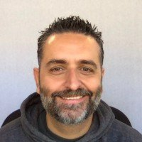

**Albert Saiz** is the Daniel Rose Associate Professor of Urban Economics and Real Estate at the Massachusetts Institute of Technology (MIT) and previously served as the Director of the MIT Center for Real Estate from 2014 to 2018.

Saiz is the Director of MIT’s Urban Economics Lab, which conducts research on topics such as real estate economics, urban economics, housing markets, local public finance, zoning regulations, global real estate, and demographic trends impacting urban and real estate development globally. He also teaches in both the Urban Planning and Real Estate programs at MIT.

Before joining MIT, Saiz was a Research Economist at the Federal Reserve Bank of Philadelphia and an award-winning Assistant Professor of Real Estate and Economics in the MBA Core Program at The Wharton School, University of Pennsylvania.

Currently, Saiz serves as a Visiting Scholar at the Federal Reserve Bank of Philadelphia, a Research Fellow at the Institute for the Analysis of Labor (IZA) in Bonn, Germany, a Board Member of the American Real Estate and Urban Economics Association, and a Research Advisor for Buildzoom.com. He is also an Editor of the *Journal of Housing Economics*.

He earned a BA in Economics from Universitat Autònoma de Barcelona in 1995 and a PhD in Economics from Harvard University in 2002.

[In-Person & Virtual Registration](https://docs.google.com/forms/d/e/1FAIpQLSeqHtetUQEDNHD6Y1Zk2xtIynYEFNRmK8wXMc9IlIgyFNQ7Ow/viewform)

[figure not shown]